# Display seafloor climage change data

Chih-Lin Wei

2024-07-11

This data package comprises ensemble model averages of CMIP6 historical and ssp126 climate change projections for the seafloor within Argentina’s Exclusive Economic Zone (EEZ). Yearly means were calculated from five climate models: GFDL-ESM4, IPSL-CM6A-LR, MPI-ESM1-2-LR, CNRM-ESM2-1, and NorESM2-MM, as part of the Coupled Models Intercomparison Project Phase 6 (CMIP6). The ensemble averages were computed for three time periods: 1950 to 2000 (historical), 2041 to 2060 (ssp126), and 2081 to 2100 (ssp126). The export flux of particulate organic carbon (POC) at the seafloor was derived from export production at 100 meters depth (epc100) using the Martin curve (Martin et al., 1987). The equation for the export POC flux is given by:$Flux = epc100*(depth/export\:depth)^{-0.858}$.

The depth information is based on the [etopo2022](https://www.ncei.noaa.gov/products/etopo-global-relief-model) dataset, and the export depth was fixed at 100 meters. Additionally, we calculated the aragonite saturation state (aragsat) and calcite saturation state (calcsat) as the ratio of carbonate concentration (co3) to the carbonate concentration in equilibrium with aragonite (co3satarg) and calcite (co3satcalc), respectively. It’s important to note that co3satarg and aragsat were only available from the GFDL-ESM4 and NorESM2-MM models. All CMIP6 data were download from [Earth System Grid Federation (ESGF)](https://esgf.llnl.gov/).

We can utilize this data to determine the occurrence and impact of climate change hazards on deep-sea floors. As biological communities adapt to long-term stability or variability in environmental conditions, we can establish the historical variability (standard deviation between 1951-2000) as a reference point. Climate change can then be defined as the disparity between future conditions and the historical average. Climate change hazard, meanwhile, is the ratio of climate change to historical variability. The time of emergence of climate change is identified as the point when future climate changes exceed twice the historical variability. This approach allows us to standardize climate change hazards across different variables, using their historical variability as a common unit. For instance, a specific variable’s climate hazard could be 10 or 100 times its historical variability.

This vignette provides some simple examples to visualize the data layers. First, we should load necessary R packages.

```r
library(ArgentinaSSP126)
library(ggplot2)
library(dplyr)
library(patchwork)
library(tidyr)
library(RColorBrewer)
```

In this analysis, we want to display the ensemble average of historical seafloor projections for export POC flux (epc), dissolved oxygen concentration (o2), pH values (ph), and potential temperature (thetao) from 1950 to 2000. Let’s break down the steps to construct the map:

1. Data Preparation:
- We start by subsetting and converting the RasterBrick containing epc, o2, ph, and thetao into a data frame.
- Next, we stack the data frame using the [gather](https://tidyr.tidyverse.org/reference/gather.html) function and split the stacked data frame into a list based on epc, o2, ph, and thetao.
2. Bathymetric Data and Argentina EEZ:
- The EEZ boundary (red polygon) is downloaded from [marineregions.org](https://marineregions.org/gazetteer.php?p=details&id=8466).
- The 200-m (dashed line) and 4000-m depth (solid line) contours were drawn using bathymetric data from the [etopo2022](https://www.ncei.noaa.gov/products/etopo-global-relief-model) dataset.

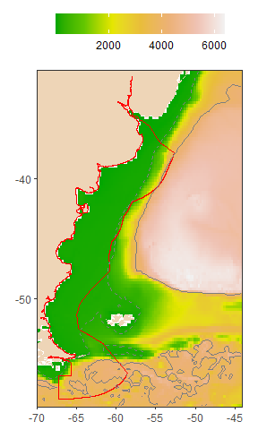

```r
bathy <- etopo2022%>% as.data.frame(xy = TRUE) %>% na.omit
ggplot(bathy) +
      geom_raster(aes(x=x, y=y, fill=-layer))+
      geom_polygon(data=arg, aes(x=X, y=Y, group=PID), fill="bisque2", colour="transparent")+
      geom_polygon(data=fortify(eez), aes(x=long, y=lat, group=id), fill="transparent", colour="red")+
      geom_contour(data=bathy, aes(x=x, y=y, z=layer), breaks=-200, linetype=2, colour="gray50")+
      geom_contour(data=bathy, aes(x=x, y=y, z=layer), breaks=-4000, linetype=1, colour="gray50")+
      scale_fill_gradientn(colours=terrain.colors(7))+
      scale_x_continuous(expand = expansion(mult = 0))+
      scale_y_continuous(expand = expansion(mult = 0))+
      labs(x=NULL, y=NULL, fill=NULL)+
      coord_fixed(1.52)+
      theme_bw() %+replace% theme(legend.position = "top", legend.key.width =  unit(1, 'cm'))
```

3. Multipanel Maps with ggplot:
- We create multipanel maps using [ggplot](https://ggplot2.tidyverse.org/). Each panel corresponds to one of the four variables (epc, o2, ph, thetao).
- To ensure independent color keys for each panel, we create a ggplot list of four maps. Finally, we wrap the ggplot list using wrap_plots.
4. Custom Plot Function:
- For convenience, we define a custom plot function with three parameters:
  - r: A rasterbrick containing the data.
  - colours: A vector of colors to use for the color key.
  - limits: A numeric vector of length two providing quantile limits for the color key scale.

```r
plot_fun <- function(r, colours=NULL, q_limits=c(0.001, 0.999)){

  # Convert raster to data frame and then to list
  cmip6_list <- as.data.frame(r, xy = TRUE) %>% na.omit %>%
  gather(-x, -y, key = "var", value = "value") %>%
  group_split(var)

  # Depth
  bathy <- etopo2022%>% as.data.frame(xy = TRUE) %>% na.omit

  # ggolot list
  gg_list = lapply(cmip6_list, function(dat) {

    # Color key limits and colours
    lim1 <- quantile(dat$value, q_limits, na.rm=TRUE)
    lim2 <- max(abs(quantile(dat$value, q_limits, na.rm=TRUE)))
    if(min(lim1) >= 0) {
      lims <- lim1; cols <- jet.colors(7)
    } else {
      lims <- c(-lim2, lim2); cols <- jet.colors3(7)}
    if(is.null(colours)) cols <- cols else cols <- colours

    # Plot raster layer
    ggplot(dat) +
      geom_raster(aes(x=x, y=y, fill=value))+
      geom_polygon(data=arg, aes(x=X, y=Y, group=PID), fill="bisque2", colour="transparent")+
      geom_polygon(data=fortify(eez), aes(x=long, y=lat, group=id), fill="transparent", colour="red")+
      geom_contour(data=bathy, aes(x=x, y=y, z=layer), breaks=-200, linetype=2, colour="gray50")+
      geom_contour(data=bathy, aes(x=x, y=y, z=layer), breaks=-4000, linetype=1, colour="gray50")+
      scale_fill_gradientn(colours=cols, limits=lims)+
      scale_x_continuous(expand = expansion(mult = 0))+
      scale_y_continuous(expand = expansion(mult = 0))+
      labs(x=NULL, y=NULL, fill=NULL)+
      coord_fixed(1.52)+
      facet_wrap(~ var) +
      theme_bw() %+replace% theme(legend.position = "top", legend.key.width =  unit(1, 'cm'))
      })

  # Wrap ggplot list
  wrap_plots(gg_list, nrow=1)
}
```

Here we used new function to plot the historical projections of export POC flux (epc), dissolved oxygen concentration (o2), pH values (ph), and potential temperature (thetao) from 1950 to 2000.

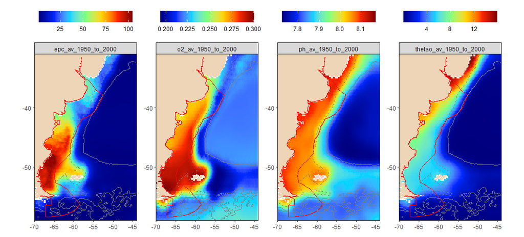

```r
plot_fun(r=cmip6_1950_2000_av %>% subset(1:4), q_limits = c(0, 1))
```

The historical standard deviation of export POC flux (epc), dissolved oxygen concentration (o2), pH values (ph), and potential temperature (thetao) from 1950 to 2000 can also be displayed in the same manner.

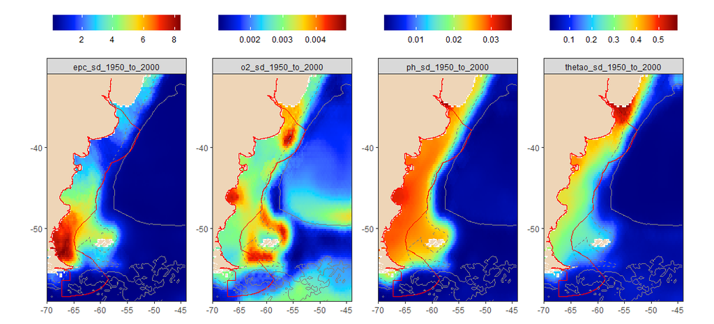

```r
plot_fun(cmip6_1950_2000_sd %>% subset(1:4), q_limits = c(0, 1))
```

The seafloor projections from 2041 to 2060 can be plotted in the same way using the ensemble average.

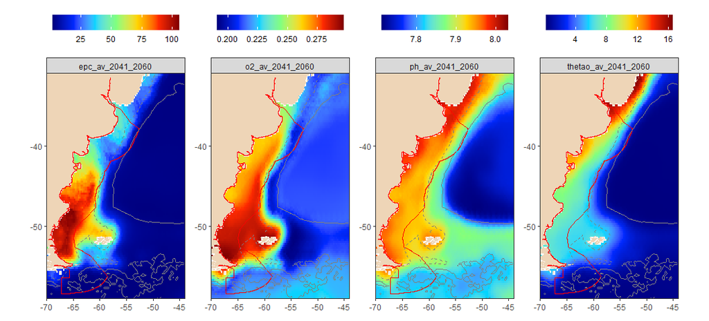

```r
plot_fun(cmip6_2041_2060_av %>% subset(1:4), q_limits = c(0, 1))
```

We then plot the climate changes as the the difference between 1950 and 2000 and 2041 to 2060. Here, we should modify the color key to visualize the difference better.

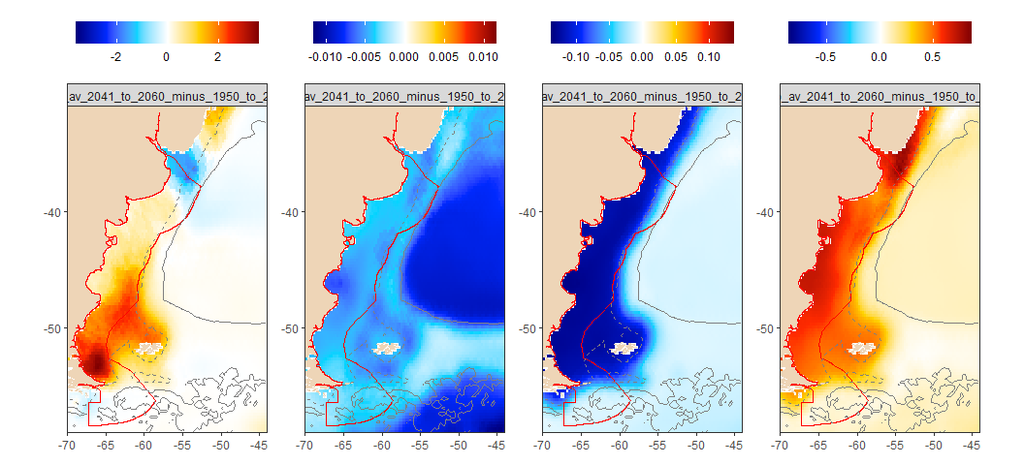

```r
plot_fun(cmip6_2041_2060_ch %>% subset(1:4), q_limits = c(0, 1))
```

The custom plot function can visually display the relationship between climate change hazards and historical standard deviation. The color indicates the degree of climate change in terms of historical variability.

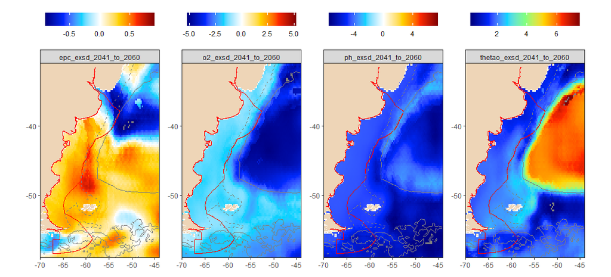

```r
plot_fun(r=cmip6_2041_2060_exsd %>% subset(1:4))
```

We can identify the years when climate changes exceed two times the historical standard deviation (or the year when the value of climate change hazards > 2). We use two times the standard deviation because in a roughly normal data set, values within one standard deviation of the mean make up about 68% of the set, while values within two standard deviations make up about 95%.

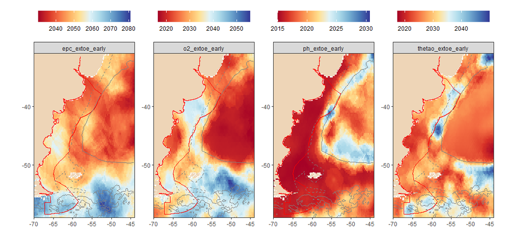

```r
plot_fun(cmip6_extoe_early %>% subset(1:4), colours = brewer.pal(10, 'RdYlBu'), q_limits = c(0, 1))
```

Here, we combine the four panels above to demonstrate the years when climate changes for export POC flux, dissolved oxygen, pH, and temperature simultaneously exceed twice the historical variability.

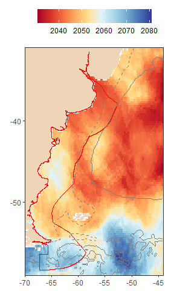

```r
all <- overlay(subset(cmip6_extoe_early, 1:4), fun=max) %>% as.data.frame(xy = TRUE) %>% na.omit
bathy <- etopo2022%>% as.data.frame(xy = TRUE) %>% na.omit
ggplot(all) +
      geom_raster(aes(x=x, y=y, fill=layer))+
      geom_polygon(data=arg, aes(x=X, y=Y, group=PID), fill="bisque2", colour="transparent")+
      geom_polygon(data=fortify(eez), aes(x=long, y=lat, group=id), fill="transparent", colour="red")+
      geom_contour(data=bathy, aes(x=x, y=y, z=layer), breaks=-200, linetype=2, colour="gray50")+
      geom_contour(data=bathy, aes(x=x, y=y, z=layer), breaks=-4000, linetype=1, colour="gray50")+
      scale_fill_gradientn(colours=brewer.pal(10, 'RdYlBu'))+
      scale_x_continuous(expand = expansion(mult = 0))+
      scale_y_continuous(expand = expansion(mult = 0))+
      labs(x=NULL, y=NULL, fill=NULL)+
      coord_fixed(1.52)+
      theme_bw() %+replace% theme(legend.position = "top", legend.key.width =  unit(1, 'cm'))
```

Another application involves calculating the cumulative impacts of climate change hazards. These hazards are caused by declining export POC flux, deoxygenation, ocean acidification, and ocean warming, and are considered to have cumulative negative impacts. On the contrary, increasing export POC flux, oxygenation, ocean basification, and ocean cooling can be considered to have cumulative positive impacts. Here, we have also created a function to calculate cumulative negative and positive impacts caused by climate change hazards.

```r
cum_imp <- function(r){
  # Negative cumulative impact (exposure to climate change hazards for epc<0, o2<0, ph<0, and thetao>0)
  n2050 <- addLayer(calc(subset(r, 1:3), fun=function(x){x[x>0]<-NA; return(-x)}),
                    calc(subset(r, 4), fun=function(x){x[x<0]<-NA; return(x)})
                    ) %>%　overlay(fun=function(x)sum(x, na.rm=T))

  # Positive cumulative impact (exposure to climate change hazards for epc>0, o2>0, ph>0, and thetao<0)
  p2050 <- addLayer(calc(subset(r, 1:3), fun=function(x){x[x<0]<-NA; return(x)}),
                    calc(subset(r, 4), fun=function(x){x[x>0]<-NA; return(-x)})
                    ) %>%　overlay(fun=function(x)sum(x, na.rm=T))

  out <- addLayer(n2050, p2050)
  names(out) <- c("Negative", "Positive")
  out <- mask(out, etopo2022)
  return(out)
}
```

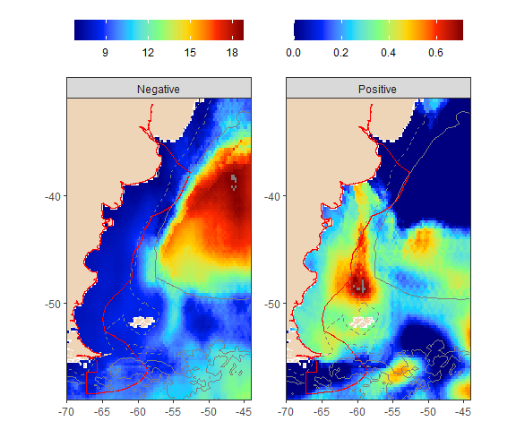

```r
plot_fun(r=cum_imp(cmip6_2041_2060_exsd))
```

An important factor for the survival of species is how quickly they need to move to adjust to current environmental conditions and keep up with climate changes. Local climate velocity can be calculated by measuring the rate of change of a specific variable (like temperature) over time and dividing it by the corresponding spatial gradient of that variable within a 3x3 area. Areas with low local climate velocities may be good candidates for protection, as they could potentially act as climatic refuges and are often associated with high levels of endemic species. It’s important to note that in deep seafloor environments, like the abyssal plain, the spatial gradient may be small, resulting in high climate velocities. In our example, we display the average seafloor gradient-based climate velocity magnitudes from 2041 to 2060.

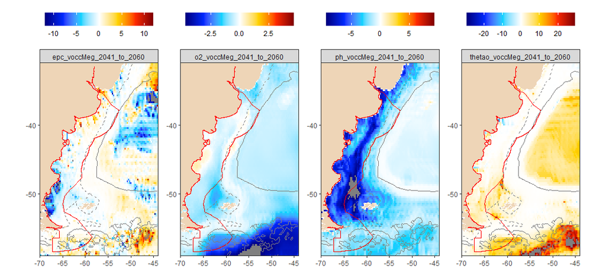

```r
plot_fun(cmip6_2041_2060_voccMeg %>% subset(1:4), q_limits=c(0.01, 0.99))
```

We can calculate the overall negative impact of climate velocity by taking into account the impacts of decreasing food supply, deoxygenation, acidification, and warming, as well as the positive impact of increasing food supply, oxygen levels, ocean basification, and cooling. Conversely, the increase in export POC flux, oxygen levels, ocean basification, and ocean cooling can be considered as cumulative positive impacts.

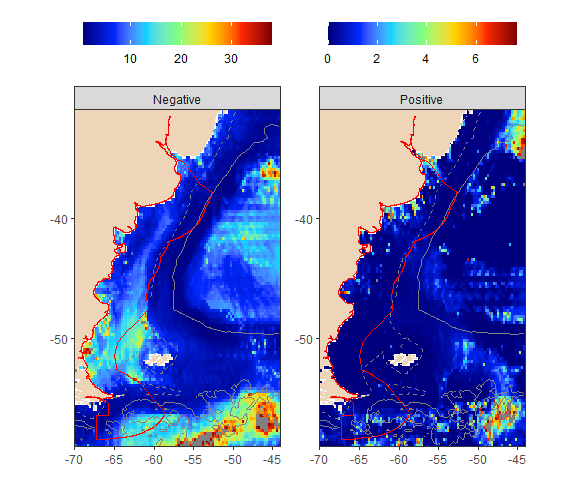

```r
plot_fun(r=cum_imp(cmip6_2041_2060_voccMeg), q_limits = c(0, 0.99))
```